# MEE paper use_case — Ecological stability & technological congruence

Author

Emma Belaud

# Overview

This document provides the full reproducible analysis for the ecological use-case section of the manuscript *“Automated processing for in situ soil monitoring: from raw images to population dynamics”*. It addresses two integrated hypotheses:

**H1 — Ecological stability:** Arboreal linear features (Position A) act as stable micro-refugia for soil invertebrate communities, whereas adjacent cultivated zones (Position C) exhibit volatile, pulsed population dynamics driven by recurrent agricultural disturbance.

**H2 — Technological congruence:** Ecological effect sizes derived from the automated computer vision pipeline are statistically indistinguishable from those derived via expert-validated manual classification, demonstrating that the classification pipeline preserves the scientific narrative established by human taxonomists.

Both hypotheses are tested on the same dataset using the same statistical framework, differing only in the source of taxonomic classification (manual vs. model-derived). This parallelism is intentional: it allows a direct, unbiased comparison of the two pipelines under identical analytical conditions.

# 1. Data loading & preprocessing

## 1.1 Raw classification data

The input file `combined_data.csv` is the primary output of the image processing pipeline. Each row corresponds to a single invertebrate candidate box extracted from a raw scanner image, and contains three fields: the image filename (which encodes all spatiotemporal and scanner metadata), the taxon label assigned by the automated classification model (`Model_class`), and the label assigned by a human expert annotator (`Manual_class`). Retaining both labels in the same dataframe is what enables the side-by-side comparison required for H2.

## 1.2 Explicit grid completion

A crucial methodological step in count-based ecological time series is to distinguish **biological zeros** (a taxon was genuinely absent during an observation window) from **technical gaps** (the sensor was offline and no image was acquired). Conflating the two can severely bias temporal variability estimates: a taxon undetected during a sensor gap would spuriously appear as a zero, inflating the CV.

We address this by creating a fully explicit spatio-temporal grid containing every possible combination of time slot × scanner unit, then left-joining the observed detections onto it. Rows without a matching detection receive `NA` for `image_name`, recorded as `image_present = FALSE`. This boolean flag is later used by the rolling stability function to apply the 5% missingness quality filter.

# 2. Hypothesis 1 — Ecological stability

## 2.1 Rationale and stability metric

Population stability is operationally defined as the **inverse of temporal variability**. We quantify variability using the **Coefficient of Variation (CV)**, computed within a rolling 7-day window (28 consecutive 6-hour observations). The CV (σ/μ) is dimensionless, which makes it comparable across taxa with very different mean abundance levels — a key requirement when contrasting organisms as disparate as Acari and Lumbricidae.

A high CV indicates a “pulsed” dynamic: the population fluctuates strongly over short periods, the expected signature of a cultivated environment. A low CV indicates a stable, buffered dynamic consistent with the relatively undisturbed arboreal linear feature.

The 7-day window was selected as an ecologically meaningful unit that smooths sub-daily stochastic variation while remaining sensitive to week-scale population pulses. A formal sensitivity analysis across window sizes from 3 to 13 days is reported to verify that the directional conclusions are robust to this choice.

## 2.2 Rolling stability function

The function below encapsulates the full rolling CV calculation, including quality control. It is designed to be applied independently to each taxon–scanner–position combination via `purrr::map()`, ensuring complete analytical parallelism across the community.

## 2.3 Applying the stability framework

Before computing rolling CVs, raw detection counts are aggregated to the scanner–day–time-slot level and supplemented with structural zeros. The `complete()` call is critical: it inserts explicit `activity = 0` rows for every taxon–scanner–slot combination where the taxon was not observed but the sensor was operational — these are biological zeros, not missing data.

A minimum detection threshold of 10 observations per taxon excludes taxa with insufficient data for stable CV estimation. `purrr::map()` then applies `compute_rolling_stability()` independently within each taxon × position × scanner-orientation group, preserving the nested structure of the experimental design (two scanners per position).

## 2.4 Exploratory visualisation

Before fitting models, we visualise the raw temporal dynamics for each taxon across the four individual scanner units. Each vertical spike represents a single 6-hour log-transformed count. The spike map allows visual inspection of the “pulsed vs. stable” contrast that H1 seeks to formally test, and confirms that the differences between positions are biologically interpretable rather than artefactual.

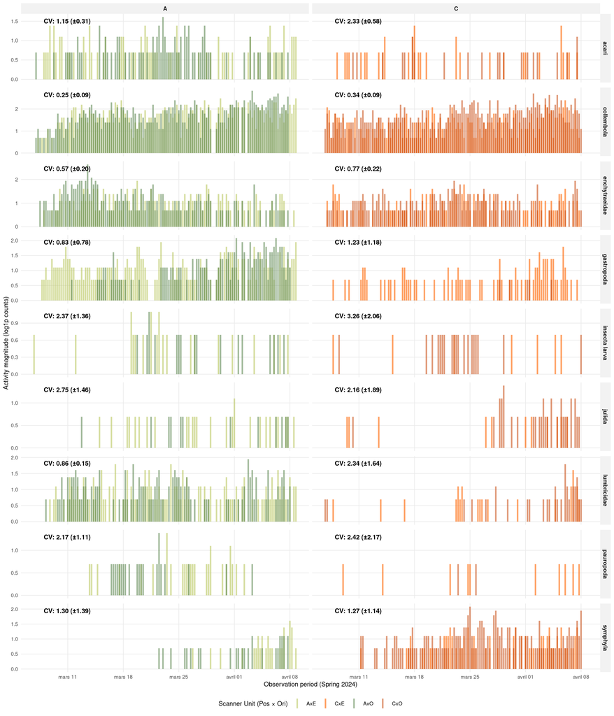

Figure 1: Temporal activity dynamics across four independent scanners (Position × Orientation). Each vertical spike represents a log-transformed 6-hour detection count. Text annotations give the mean (±SD) rolling CV per land-use treatment.

## 2.5 Sensitivity analysis — Window duration

The choice of a 7-day rolling window is ecologically motivated but analytically arbitrary. We test whether the directional contrast between arboreal and cultivated positions is robust by repeating the rolling CV calculation for window sizes of 3, 5, 7, 9, 11, and 13 days. A consistent separation between positions across all window sizes supports the 7-day choice and rules out artefactual results.

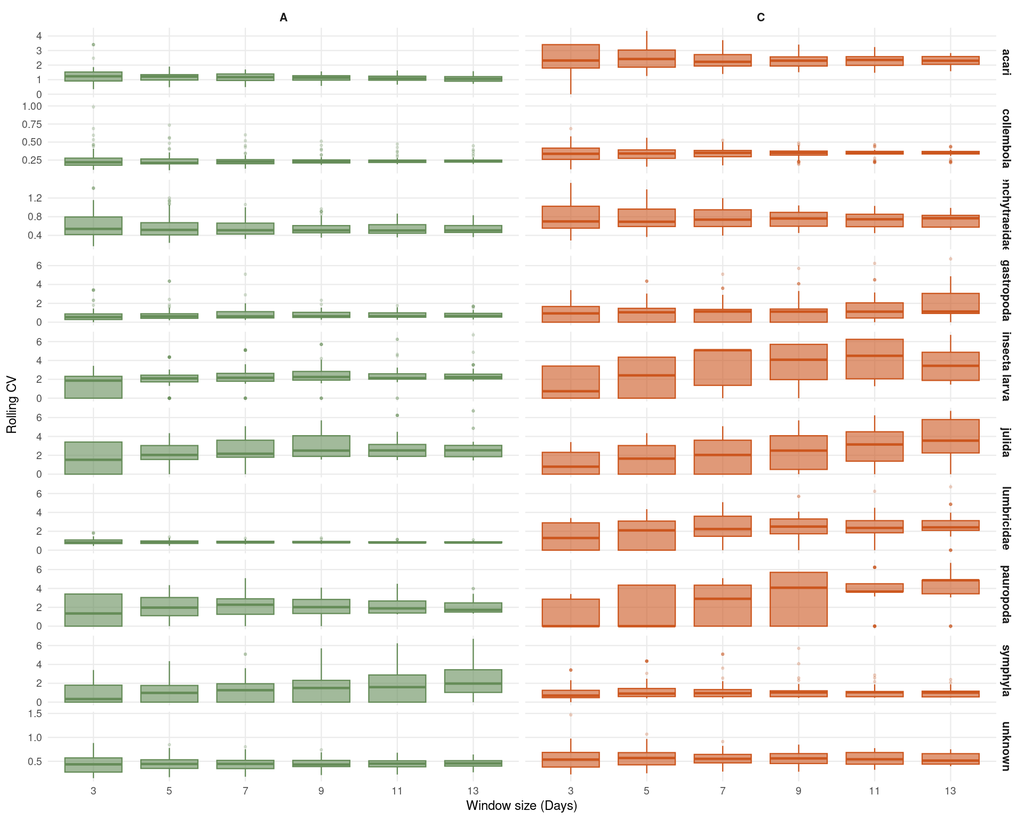

# 3. Statistical modelling (H1)

## 3.1 Model specification

Rolling CV values are strictly positive and right-skewed, making standard Gaussian or Poisson GLMMs inappropriate. We use **Zero-Inflated Gamma (ZIG) GLMMs** fitted with `glmmTMB`:

- The **Gamma component** (log link) models continuous, positive CV values and captures the intensity of variability as a function of land-use position.
- The **zero-inflation component** accounts for structural zeros arising in highly stable windows where SD ≈ 0, making CV = 0 after the `roll_sd / (roll_mean + 0.001)` calculation.
- An **AR1 correlation structure** is specified as a random effect over the integer time index within each scanner orientation, explicitly modelling the temporal autocorrelation inherent in rolling-window data.

However, for some taxa the AR1 correlation is near-zero or the time series is too short for the AR1 parameters to be identifiable, producing a non-positive- definite Hessian. In such cases, we fall back to a simpler random-intercept model for `orientation` (no AR1), which is more numerically stable.

The fixed effect of primary interest is `positionC` — the contrast between the cultivated zone (C) and the arboreal reference (A) on the log-link scale. A positive estimate indicates higher CV (lower stability) in position C; a negative estimate indicates the reverse. One model is fitted per taxon, allowing the land-use effect to vary freely across the community.

## 3.2 Model diagnostics

Goodness-of-fit is assessed using **DHARMa**, which generates simulation-based residual envelopes and tests for: (i) overdispersion, (ii) outliers, (iii) zero-inflation misspecification, and (iv) non-uniformity of scaled residuals. Convergence is verified via `performance::check_convergence()`.

The table below summarises all diagnostic metrics. A significant KS uniformity p-value (< 0.05) for some taxa (e.g., Collembola, Enchytraeidae) reflects the discrete, integer-count origin of the underlying data — this is expected and does not invalidate inference on the land-use fixed effect.

| Column | Description | Ecological interpretation |
| --- | --- | --- |
| Effect_Size | log-ratio of CV: Position C vs. A | Positive = more variable (less stable) in cultivated zone |
| KS_Unif | Kolmogorov–Smirnov uniformity p-value | p < 0.05 for integer-count taxa is expected; not a failure |
| Dispersion | DHARMa dispersion test p-value | p < 0.05 indicates Gamma variance assumption may be violated |

Table 1: Summary of Zero-Inflated Gamma models: ecological effect sizes and DHARMa diagnostics. Taxa are ordered from the largest to the smallest land-use effect (Position C vs. A). Effect sizes are on the log-link scale: positive values indicate lower stability (higher CV) in the cultivated zone. Model Status: ‘Robust’ = all DHARMa checks passed; ‘Fallback RI’ = AR1 model did not converge and a random-intercept model was used instead; ‘Discrete/Non-Uniform’ = expected for integer-count taxa and is not indicative of model misspecification.

| Taxon | N | DF | Model Status | Ecological effect (Pos. C) Estimate | Ecological effect (Pos. C) SE | Ecological effect (Pos. C) p-value | Ecological effect (Pos. C) Sig | DHARMa P-values KS Unif. | DHARMa P-values Dispersion |
| --- | --- | --- | --- | --- | --- | --- | --- | --- | --- |
| lumbricidae | 103 | 97 | Fallback RI (no AR1) | 1.244 | 0.062 | 0.000 | *** | 0.364 | 0.184 |
| gastropoda | 103 | 96 | Discrete/Non-Uniform | 1.124 | 0.081 | 0.000 | *** | 0.001 | 0.712 |
| acari | 103 | 96 | Robust | 0.711 | 0.046 | 0.000 | *** | 0.942 | 0.856 |
| pauropoda | 103 | 96 | Robust | 0.696 | 0.058 | 0.000 | *** | 0.072 | 0.244 |
| collembola | 103 | 96 | Discrete/Non-Uniform | 0.323 | 0.038 | 0.000 | *** | 0.000 | 0.904 |
| insecta larva | 103 | 96 | Robust | 0.321 | 0.071 | 0.000 | *** | 0.135 | 0.700 |
| enchytraeidae | 103 | 96 | Discrete/Non-Uniform | 0.309 | 0.030 | 0.000 | *** | 0.000 | 0.940 |
| julida | 103 | 96 | Robust | 0.107 | 0.081 | 0.183 | ns | 0.198 | 0.888 |
| symphyla | 103 | 96 | Discrete/Non-Uniform | -1.097 | 0.058 | 0.000 | *** | 0.000 | 0.420 |

## 3.3 Results

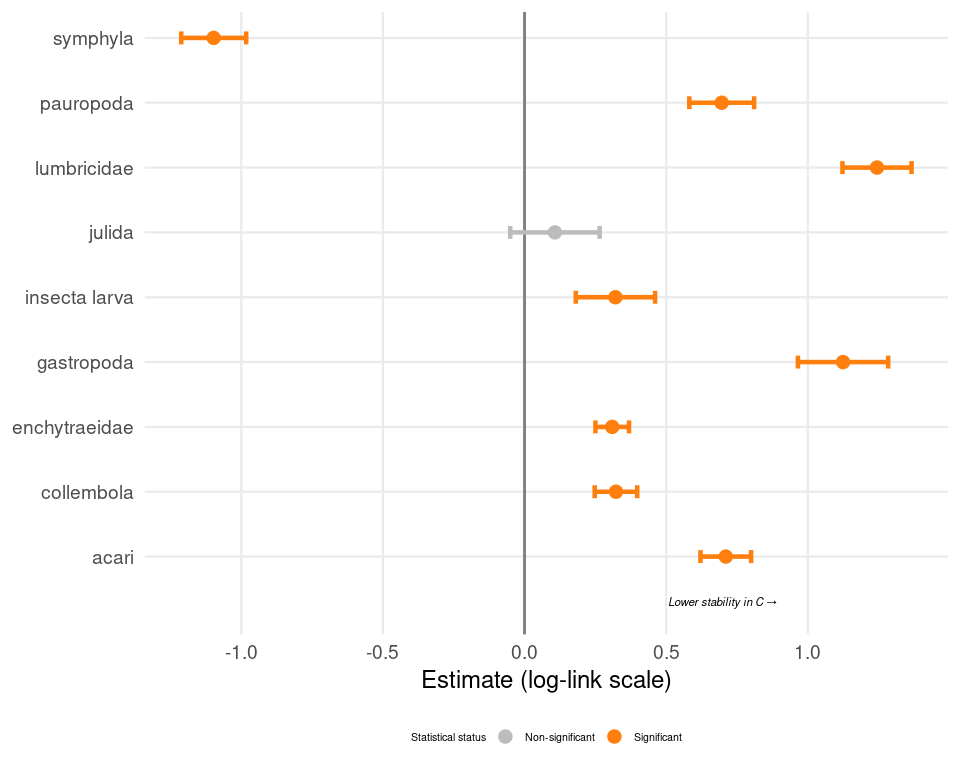

Table 2: Generalized Linear Mixed Model (ZIG) parameters for the effect of land-use position on population stability (rolling CV). Estimates are on the log-link scale, where positive values indicate higher variability (lower stability) in cultivated zones.

| Taxon | Estimate | Std. Error | z-value | p-value | Significance |
| --- | --- | --- | --- | --- | --- |
| Acari | 0.711 | 0.046 | 15.577 | <0.001 | Significant |
| Collembola | 0.323 | 0.038 | 8.433 | <0.001 | Significant |
| Enchytraeidae | 0.309 | 0.030 | 10.231 | <0.001 | Significant |
| Gastropoda | 1.124 | 0.081 | 13.835 | <0.001 | Significant |
| Insecta Larva | 0.321 | 0.071 | 4.493 | <0.001 | Significant |
| Julida | 0.107 | 0.081 | 1.332 | 0.183 | Non-significant |
| Lumbricidae | 1.244 | 0.062 | 20.010 | <0.001 | Significant |
| Pauropoda | 0.696 | 0.058 | 11.927 | <0.001 | Significant |
| Symphyla | -1.097 | 0.058 | -18.764 | <0.001 | Significant |

# 4. Hypothesis 2 — Technological congruence

## 4.1 Rationale

H2 tests whether the automated pipeline can be trusted to replace manual classification for ecological inference. The key question is not whether the model produces identical counts to a human expert — it will not — but whether the **downstream ecological effect sizes** are preserved. If the land-use effect estimated from model-classified data is congruent with the effect estimated from manually classified data, the pipeline can be considered ecologically valid.

We assess congruence using a **1:1 identity plot**: taxa falling on or near the y = x line show perfect agreement; systematic deviations reveal directional biases in the automated classifier.

## 4.2 Replicating the H1 pipeline on model-classified data

The identical preprocessing, rolling stability, and GLMM workflow from H1 is applied here, substituting `Model_class` for `Manual_class` as the taxonomic classification source. This procedural parallelism is essential: any difference in the resulting effect sizes must be attributable to classification accuracy, not to analytical choices.

## 4.3 Extracting and comparing effect sizes

Fixed-effect estimates for `positionC` are extracted from both the manual and model-derived pipelines and joined by taxon. The absolute difference (|Δ|) quantifies the per-taxon discrepancy. Taxa with |Δ| close to zero are perfectly congruent; larger values indicate where the automated classifier introduces the most bias in ecological inference. Only taxa present in both pipelines (inner join) are included, ensuring the comparison is always perfectly paired.

## 4.4 Results

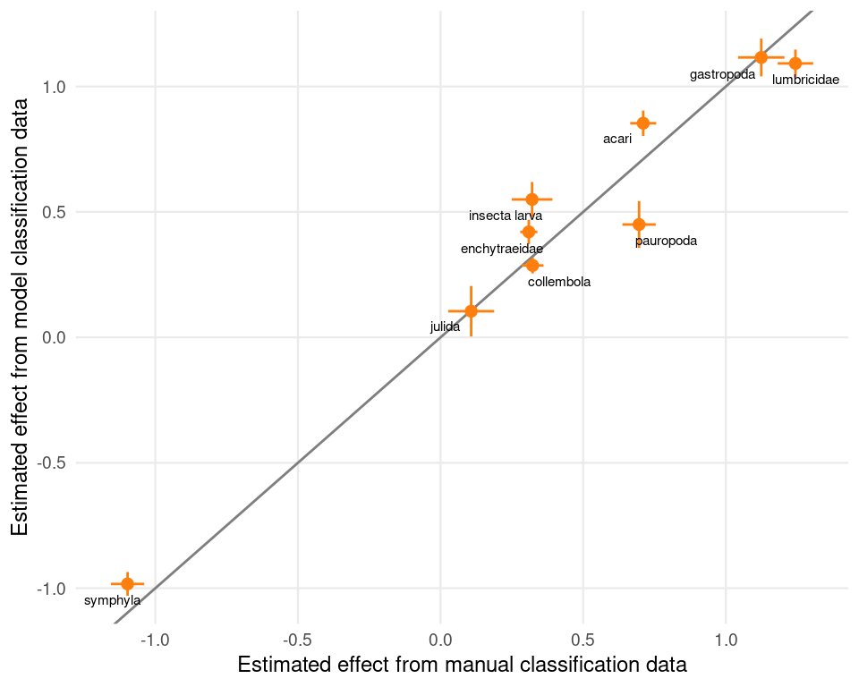

Figure 4: Technological congruence (H2): land-use effect sizes (Position C vs. A) from the manual and automated pipelines. The grey line is the 1:1 identity reference. Error bars span ± 1 SE. Taxa close to the identity line show high cross-pipeline agreement.

Table 3: Comparison of ecological effect size estimates between human taxonomists and the automated classification pipeline. ‘Diff’ represents the absolute discrepancy between manual and model-derived estimates.

| Taxon | Manual pipeline Est (Human) | Manual pipeline SE (Human) | Model pipeline Est (Model) | Model pipeline SE (Model) | Abs. Diff |
| --- | --- | --- | --- | --- | --- |
| Acari | 0.711 | 0.046 | 0.854 | 0.051 | 0.143 |
| Collembola | 0.323 | 0.038 | 0.287 | 0.032 | 0.036 |
| Enchytraeidae | 0.309 | 0.030 | 0.420 | 0.048 | 0.111 |
| Gastropoda | 1.124 | 0.081 | 1.116 | 0.075 | 0.009 |
| Insecta Larva | 0.321 | 0.071 | 0.550 | 0.070 | 0.229 |
| Julida | 0.107 | 0.081 | 0.104 | 0.101 | 0.003 |
| Lumbricidae | 1.244 | 0.062 | 1.092 | 0.055 | 0.152 |
| Pauropoda | 0.696 | 0.058 | 0.450 | 0.093 | 0.246 |
| Symphyla | -1.097 | 0.058 | -0.983 | 0.048 | 0.114 |